# Multi-Task Omics — `multibench` end-to-end tutorial

This notebook walks the complete user story for the **`multibench`** wrapper around the scMultiBench integration methods:

```
inputs_for  →  params_for  →  run  →  evaluate  →  plot
 (data)        (tuning)      (method)  (metrics)   (figure)
```

Everything here is **run-verified** on one reference dataset, **D11** (CITE-seq PBMC, 2,864 cells, RNA + ADT). All **14** methods that support the `vertical [rna, adt]` scenario were executed end-to-end on it.

> **Why D11?** Integration methods are defined by the scenario they solve, so no single dataset can exercise all 40 methods. D11 is the largest set of methods (14) that share one dataset, and at 2,864 cells it is small enough that you can actually re-run this notebook.

## 0. Setup

Run this notebook in the driver environment (`scmbench_eval`).

```python
%matplotlib inline

import warnings
warnings.filterwarnings("ignore")

import pandas as pd
import multibench as mtb

print("multibench", mtb.__version__)

from pathlib import Path
# verified sweep results shipped next to this notebook
RESULTS = Path("results")
```

```
multibench 0.1.0
```

### Environments

Each method runs in its **own conda environment** (they need mutually incompatible framework versions). The package maps method → env for you, and ships lockfiles so a fresh machine can rebuild them.

```
multibench env doctor          # what is needed / missing
multibench env install --run   # build everything from lockfiles
```

```python
DATASET  = "D11"
CATEGORY = "vertical"
MODALITIES = ["rna", "adt"]

METHODS = ["Concerto", "MOFA2", "Matilda", "Multigrate", "Seurat_WNN", "UINMF",
           "VIMCCA", "moETM", "scMDC", "scMM", "scMSI", "scMoMaT", "sciPENN", "totalVI"]

pd.DataFrame([{"method": m, "env": mtb.env.group_for(m)} for m in METHODS])
```

|  | method | env |
| --- | --- | --- |
| 0 | Concerto | scmb_concerto |
| 1 | MOFA2 | MOFA2_env |
| 2 | Matilda | matilda |
| 3 | Multigrate | scmb_multigrate2 |
| 4 | Seurat_WNN | liger |
| 5 | UINMF | scmb_r |
| 6 | VIMCCA | scmb_vimcca |
| 7 | moETM | env_moETM |
| 8 | scMDC | scmb_scmdc |
| 9 | scMM | scmb_scmm2 |
| 10 | scMSI | scmb_scmsi |
| 11 | scMoMaT | scmb_torch |
| 12 | sciPENN | env_sciPENN |
| 13 | totalVI | scmb_scvi |

## 1. Discovery — which methods fit my data?

`find_methods` filters the registry; `method_info` describes one method.

```python
vertical_rna_adt = mtb.find_methods(category="vertical", modalities=["rna", "adt"])
print(len(vertical_rna_adt), "methods support vertical [rna, adt]")
print(sorted(vertical_rna_adt))
```

```
14 methods support vertical [rna, adt]
['Concerto', 'MOFA2', 'Matilda', 'Multigrate', 'Seurat_WNN', 'UINMF', 'VIMCCA', 'moETM', 'scMDC', 'scMM', 'scMSI', 'scMoMaT', 'sciPENN', 'totalVI']
```

```python
info = mtb.method_info("Matilda")
{k: info[k] for k in ("id", "language", "categories", "tasks", "env", "status")}
```

```
{'id': 'Matilda',
 'language': 'python',
 'categories': ['vertical'],
 'tasks': ['dimension_reduction', 'classification'],
 'env': 'matilda',
 'status': 'verified'}
```

## 2. Data — resolve the inputs

`inputs_for` maps a dataset + method + scenario to the concrete files that method expects. `check=True` verifies they exist, so you fail fast instead of mid-run.

```python
inputs = mtb.inputs_for(DATASET, "Matilda", CATEGORY,
                       modalities=MODALITIES, check=True)
inputs
```

```
{'rna': '/media/disk2/Sichang/scmbench_pkg/data/D11/rna.h5',
 'adt': '/media/disk2/Sichang/scmbench_pkg/data/D11/adt.h5',
 'cty': '/media/disk2/Sichang/scmbench_pkg/data/D11/cty.csv'}
```

```python
# cell-type labels used later for the metrics
mtb.labels_for(DATASET)
```

```
{'cty': '/media/disk2/Sichang/scmbench_pkg/data/D11/cty.csv'}
```

## 3. Parameters — what can I actually tune?

`params_for` reports two things:

- **`defaults`** — parameters the wrapper passes on every run. Override them with `run(..., params={...})`.
- **`tunable`** — parameters the **upstream script** accepts on its command line, with their upstream defaults.

> **An honest limitation.** Only the parameters a method exposes on its CLI can be tuned, because this project never modifies the upstream method scripts. Of the 14 methods here, **5** expose hyperparameters; the other **9 hardcode them** and report `tunable: {}`. That is a property of the methods, not a gap in the wrapper.

```python
p = mtb.params_for("Matilda", CATEGORY, MODALITIES)
print("defaults:", p["defaults"])
print("tunable :", list(p["tunable"])[:10])
```

```
defaults: {'epochs': 30, 'seed': 1, 'device': 'auto'}
tunable : ['augmentation', 'batch_size', 'device', 'epochs', 'hidden_adt', 'hidden_atac', 'hidden_rna', 'lr', 'seed', 'z_dim']
```

```python
rows = []
for m in METHODS:
    q = mtb.params_for(m, CATEGORY, MODALITIES)
    rows.append({"method": m, "n_tunable": len(q["tunable"]),
                 "defaults": q["defaults"],
                 "example_tunable": ", ".join(sorted(q["tunable"])[:4]) or "(none - hardcoded upstream)"})
pd.DataFrame(rows).sort_values("n_tunable", ascending=False).reset_index(drop=True)
```

|  | method | n_tunable | defaults | example_tunable |
| --- | --- | --- | --- | --- |
| 0 | scMDC | 24 | {'nbatch': 1} | batch_size, cutoff, data_file, device |
| 1 | scMM | 19 | {'model': 'rna_protein', 'no_cuda': True} | analytics, batch_size, deterministic_warmup, e... |
| 2 | Matilda | 10 | {'epochs': 30, 'seed': 1, 'device': 'auto'} | augmentation, batch_size, device, epochs |
| 3 | Multigrate | 3 | {'epochs': 200, 'bs': 256, 'lr': 0.001} | bs, epochs, lr |
| 4 | sciPENN | 1 | {} | seed |
| 5 | Concerto | 0 | {} | (none - hardcoded upstream) |
| 6 | MOFA2 | 0 | {} | (none - hardcoded upstream) |
| 7 | Seurat_WNN | 0 | {} | (none - hardcoded upstream) |
| 8 | UINMF | 0 | {} | (none - hardcoded upstream) |
| 9 | VIMCCA | 0 | {} | (none - hardcoded upstream) |
| 10 | moETM | 0 | {} | (none - hardcoded upstream) |
| 11 | scMSI | 0 | {} | (none - hardcoded upstream) |
| 12 | scMoMaT | 0 | {} | (none - hardcoded upstream) |
| 13 | totalVI | 0 | {} | (none - hardcoded upstream) |

## 4. Run a method

`run` builds the command, executes it inside the method's own conda env, and loads the output back. **Method scripts are never modified.**

We pass `params={"epochs": 5}` to keep this demo quick — that is the tuning API from the previous section doing real work.

```python
res = mtb.run(method="Matilda", category=CATEGORY, inputs=inputs,
              out_dir="/tmp/tutorial/Matilda_D11",
              params={"epochs": 5})

emb = res.output
print("embedding:", emb.shape)
```

```
embedding: (2864, 100)
```

### ⚠️ Not every method returns an embedding

Check `output.kind` before you compute embedding-based metrics. Of these 14 methods, **12 return `embedding`** and **2 return `graph`**:

| method | kind | what it writes |
| --- | --- | --- |
| `Seurat_WNN` | `graph` | a weighted nearest-neighbour graph — **no embedding at all** |
| `scMoMaT` | `graph` | KNN indices/distances; a 2-D UMAP lives in `extra_outputs` |

Running clustering metrics on a KNN **index matrix** silently produces garbage (ARI ≈ 0), so branch on `kind` rather than assuming.

```python
from multibench.engine import registry

rows = []
for m in METHODS:
    v = registry.get(m).select(CATEGORY, set(MODALITIES))
    rows.append({"method": m, "kind": v.output.kind, "file": v.output.file,
                 "extra": ", ".join(f"{o.kind}:{o.file}" for o in v.extra_outputs) or "-"})
pd.DataFrame(rows).sort_values("kind").reset_index(drop=True)
```

|  | method | kind | file | extra |
| --- | --- | --- | --- | --- |
| 0 | Concerto | embedding | embedding.h5 | - |
| 1 | MOFA2 | embedding | embedding.h5 | - |
| 2 | Matilda | embedding | embedding.h5 | labels:predict.csv |
| 3 | Multigrate | embedding | embedding.h5 | - |
| 4 | UINMF | embedding | embedding.h5 | - |
| 5 | VIMCCA | embedding | embedding.h5 | - |
| 6 | moETM | embedding | embedding.h5 | - |
| 7 | scMDC | embedding | embedding.h5 | - |
| 8 | scMM | embedding | embedding.h5 | - |
| 9 | scMSI | embedding | embedding.h5 | - |
| 10 | sciPENN | embedding | embedding.h5 | - |
| 11 | totalVI | embedding | embedding.h5 | - |
| 12 | Seurat_WNN | graph | dist.h5 | graph:idx.h5 |
| 13 | scMoMaT | graph | knn_indices.h5 | graph:knn_dists.h5, embedding:umap_embedding.h5 |

## 5. Evaluate — scIB metrics

`evaluate` derives an optimal-resolution Leiden clustering from the embedding and scores it against the true cell types (the standard scIB protocol). Pass the label vector in the embedding's **cell order**.

```python
import numpy as np

labels = pd.read_csv(mtb.labels_for(DATASET)["cty"])
labels = labels["x"].to_numpy() if "x" in labels.columns else labels.iloc[:, -1].to_numpy()

scores = mtb.evaluate(emb, category=CATEGORY, task="clustering", labels=labels)
scores
```

```
Cluster for cluster_0.2 with leiden
Cluster for cluster_0.4 with leiden
Cluster for cluster_0.6 with leiden
```

```
Cluster for cluster_0.8 with leiden
Cluster for cluster_1.0 with leiden
Cluster for cluster_1.2 with leiden
```

```
Cluster for cluster_1.4 with leiden
Cluster for cluster_1.6 with leiden
```

```
Cluster for cluster_1.8 with leiden
Cluster for cluster_2.0 with leiden
```

```
isolated labels: []
isolated labels: []
```

[output not shown]

|  | Value |
| --- | --- |
| ARI | 0.873072 |
| NMI | 0.869760 |
| ASW | 0.597756 |
| iASW | NaN |
| iF1 | NaN |
| cLISI | NaN |

> `iASW` / `iF1` / `cLISI` come back `NaN` here: D11 is a single-batch dataset (the batch-integration metrics are undefined) and the scIB LISI binary needs a newer GLIBC than this host provides. The clustering metrics are unaffected.

## 6. Plot

`to_long` reshapes the scores for plotting; `plot.bubble` renders the comparison figure used throughout the benchmark.

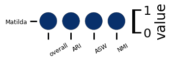

```python
long = mtb.to_long(scores, method="Matilda", dataset=DATASET, category=CATEGORY)
fig = mtb.plot.bubble(long)
fig.set_dpi(110)
display(fig)
```

## 7. Comparing all 14 methods

Running every method takes hours (sciPENN 143 s → scMSI 2.3 h), so we load the verified results from the full sweep and plot them together.

```python
summary = pd.read_csv(RESULTS / "summary_D11.csv")
summary[["method", "status", "sec", "emb", "ARI", "NMI", "ASW"]]
```

|  | method | status | sec | emb | ARI | NMI | ASW |
| --- | --- | --- | --- | --- | --- | --- | --- |
| 0 | Concerto | CHAIN_OK | 1387.6 | [2864, 128] | 0.3724 | 0.4705 | 0.5086 |
| 1 | MOFA2 | CHAIN_OK | 868.4 | [2864, 17] | 0.4444 | 0.6691 | 0.4733 |
| 2 | Matilda | CHAIN_OK | 189.2 | [2864, 100] | 0.9238 | 0.9186 | 0.6793 |
| 3 | Multigrate | CHAIN_OK | 1276.6 | [2864, 15] | 0.6556 | 0.7643 | 0.6609 |
| 4 | UINMF | CHAIN_OK | 261.2 | [2864, 30] | 0.4983 | 0.6286 | 0.5541 |
| 5 | VIMCCA | CHAIN_OK | 548.8 | [2864, 8] | 0.5985 | 0.7300 | 0.5847 |
| 6 | moETM | CHAIN_OK | 428.3 | [2864, 100] | 0.6605 | 0.7323 | 0.5478 |
| 7 | scMDC | CHAIN_OK | 888.1 | [2864, 16] | 0.6494 | 0.7111 | 0.6104 |
| 8 | scMM | CHAIN_OK | 234.9 | [2864, 10] | 0.6939 | 0.7228 | 0.5722 |
| 9 | scMSI | CHAIN_OK | 8163.9 | [2864, 20] | 0.7518 | 0.8019 | 0.5743 |
| 10 | sciPENN | CHAIN_OK | 143.5 | [2864, 512] | 0.5839 | 0.6890 | 0.6311 |
| 11 | totalVI | CHAIN_OK | 2096.1 | [2864, 20] | 0.8206 | 0.8400 | 0.5504 |
| 12 | scMoMaT | CHAIN_OK_GRAPH_METHOD | 411.6 | [2864, 2] | 0.4469 | 0.5495 | 0.5805 |
| 13 | Seurat_WNN | RUN_OK_GRAPH_ONLY | 329.3 | [2864, 20] | NaN | NaN | NaN |

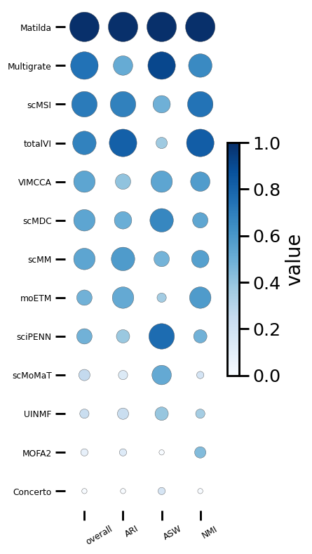

```python
all_long = pd.read_csv(RESULTS / "long_all_D11.csv")
fig = mtb.plot.bubble(all_long)
fig.set_dpi(110)
display(fig)
```

### Reading the results

- **Matilda (ARI 0.924)** and **totalVI (0.821)** lead on this dataset.
- **scMSI (0.752)** scores well but needs **2.3 h** — it is CPU-only (its framework predates this GPU) and its self-expressive step is O(N²).
- **scMoMaT (0.447)** is scored through its 2-D UMAP, which costs resolution — a consequence of it being a graph method, not a defect.
- **Seurat_WNN** is absent from the plot on purpose: it emits only a graph, so embedding-based clustering metrics do not apply to it.

Scores are dataset-specific — do not read this as a global ranking.

## Summary

| Step | API |
| --- | --- |
| pick a method | `find_methods`, `method_info` |
| resolve data | `inputs_for`, `labels_for` |
| inspect tuning | `params_for` |
| run | `run(..., params={...})` |
| metrics | `evaluate`, `to_long` |
| figure | `plot.bubble` |
| environments | `mtb.env.*`, `multibench env doctor/install` |

**Two things to remember**

1. Check `output.kind` before computing embedding metrics — 2 of these 14 methods return graphs.
2. `params_for` tells you what is genuinely tunable; a method reporting `tunable: {}` hardcodes its hyperparameters upstream.